# Lab 4: De la RNN al Transformer — una evolución visual

> *"I went to the **bank** to withdraw money."*

> *"I sat on the **bank** of the river."*

La misma palabra. Dos significados opuestos. ¿Puede una máquina distinguirlos?

Esa pregunta guía todo el lab. Recorremos cuatro arquitecturas y medimos, en cada una, si son capaces de separar los dos *bank* — hasta llegar a BERT, que sí lo consigue.

| Bloque | Arquitectura | Pregunta clave |
| --- | --- | --- |
| 1 | RNN | ¿Puede "recordar" el contexto al procesar *bank*? |
| 2 | Atención | ¿Y si cada token pudiera ver a todos los demás? |
| 3 | Transformer | ¿Cómo escalar la atención a millones de parámetros? |
| 4 | BERT / GPT | ¿Qué ganamos con los modelos pre-entrenados? |

```
✅ Todo listo
```

## 🔁 Bloque 1 — Red Neuronal Recurrente (RNN)

Una RNN lee el texto **de izquierda a derecha**, un token a la vez. En cada paso actualiza un **estado oculto** (un pequeño vector numérico) que resume lo que ha leído hasta ahora.

**¿Qué problema tiene?** El estado oculto es un vector de tamaño fijo. Si la frase es muy larga, la información del principio se "diluye" o desaparece.

**🤔 Pausa y predice — RNN**

Vamos a visualizar el estado oculto de la RNN token a token en dos frases donde *"banco"* tiene significados distintos.

¿Crees que la representación de *"banco"* será diferente en las dos frases?

**💡 Ver respuesta**

**No, será idéntica.** La RNN es unidireccional: cuando lee *"banco"* (token 2) solo ha visto *"el"*. No sabe lo que viene después. El estado en ese momento es exactamente el mismo en las dos frases — la diferencia solo aparece en los tokens posteriores, que llegan demasiado tarde.

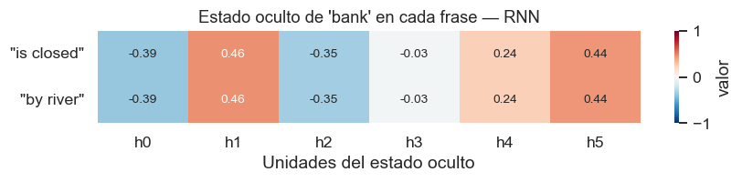

**Resultado — RNN:** similitud coseno entre los dos *bank* = **1.000**

La RNN procesa de izquierda a derecha, un token a la vez. Cuando llega a **"bank"** (posición 1), solo ha leído **"the"**. Las dos frases comparten ese prefijo → estados ocultos **idénticos** → la RNN **no puede distinguir** el banco financiero del banco fluvial.

## 👁️ Bloque 2 — Mecanismo de Atención

En lugar de comprimir toda la frase en un solo vector, la atención permite que **cada token vea el contexto de todos los demás** directamente:

$$\text{Attention}(Q, K, V) = \text{softmax}\!\left(\frac{QK^{\top}}{\sqrt{d_k}}\right)V$$

| Matriz | Significado |
| --- | --- |
| **Q** (Query) | ¿qué busca este token? |
| **K** (Key) | ¿qué ofrece cada token? |
| **V** (Value) | ¿qué información devuelve si lo seleccionan? |

El resultado es una **suma ponderada** de todos los *values* — cada token puede atender a cualquier otro, en ambas direcciones.

**🤔 Pausa y predice — Atención**

El mecanismo de atención ve *todos* los tokens a la vez, en ambas direcciones. ¿A qué token crees que prestará más atención *"banco"* (posición 2)?

**💡 Ver respuesta**

Pero aquí está la clave: ahora la representación de *"banco"* **sí depende del contexto completo** (incluyendo lo que viene después). Con entrenamiento, aprendería a pesar más *"cerrado"* o *"junto al río"* para desambiguar — eso es precisamente lo que hace BERT.

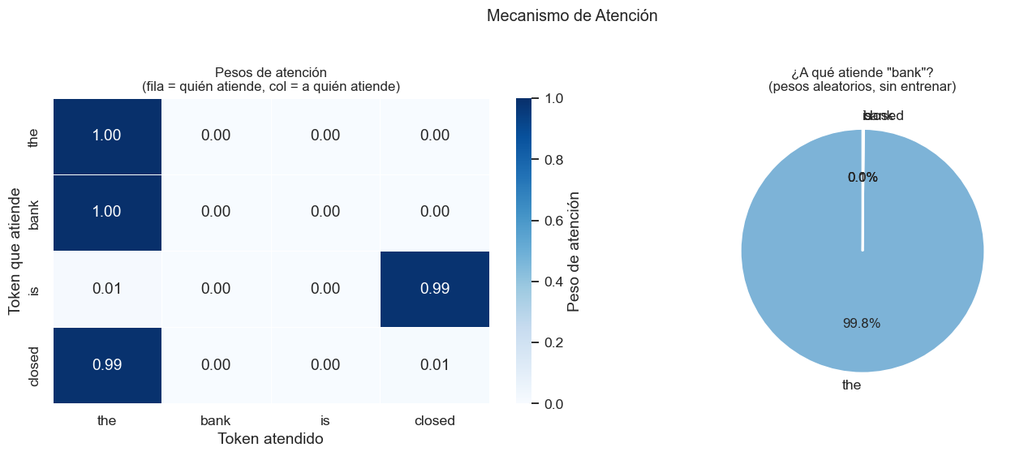

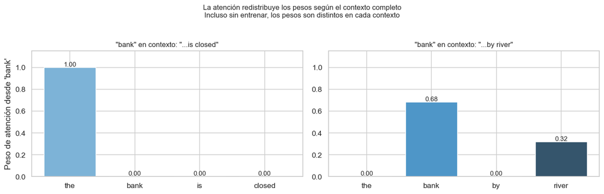

La clave no es el valor de los pesos, sino la **estructura**: la atención puede ver todos los tokens a la vez — incluyendo los que vienen después. Eso es bidireccionalidad por construcción. BERT entrenará con millones de frases y aprenderá a enfocar estos pesos según el significado del contexto.

## 🏗️ Bloque 3 — Del Transformer a BERT y GPT

|  | **BERT** | **GPT** |
| --- | --- | --- |
| Atención | Bidireccional (ve izq. y der.) | Causal (solo izquierda) |
| Pre-entrenamiento | Predice tokens enmascarados | Predice el siguiente token |
| Mejor para | Clasificación, NER, QA | Generación de texto |

Entrenar desde cero requiere millones de ejemplos y miles de horas de GPU. La solución: usar modelos **pre-entrenados en texto masivo** y aplicarlos directamente.

[figure not shown]

**🤔 Pausa y predice — BERT**

Ahora usamos BERT real, entrenado en millones de textos. ¿Crees que producirá el mismo vector para *"bank"* en estas dos frases?

- *"I went to the **bank** to withdraw money"*
- *"I sat on the **bank** of the river"*

**💡 Ver respuesta**

**No.** BERT es **bidireccional**: para generar el embedding de *"bank"*, atiende a todas las palabras de la frase — tanto las previas como las siguientes. En un caso ve *"withdraw money"*; en el otro, *"river"*. La representación final captura esa diferencia.

La similitud coseno será claramente menor que 1.0 — los dos vectores son distintos. Los valores típicos con BERT-base están entre 0.45 y 0.80 dependiendo de cuán diferentes sean los contextos.

```
Similitud coseno entre los dos 'bank': 0.476
(1.0 = idénticos  ·  cuanto menor, más distingue el contexto)
```

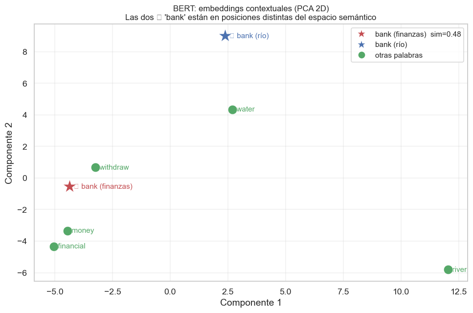

### 🤖 GPT-2 — generación autorregresiva

GPT lee de izquierda a derecha y predice el siguiente token en cada paso. Sin saber qué significa *bank*, su contexto lo lleva a completar cada frase de forma coherente:

```
"I went to the bank to get my money back. I was in"
"I sat on the bank of the river, and I saw the great river"
```

**Resultado — BERT:** las dos apariciones de *bank* ocupan posiciones **distintas** en el espacio semántico (sim = 0.476). El modelo ha aprendido que "withdraw money" y "river" llevan a representaciones separadas.

**GPT-2** confirma la misma intuición desde otro ángulo: completando cada frase de forma coherente con su contexto, aunque nunca haya visto la pregunta "¿cuál es el significado de *bank* aquí?".

## 📊 Resumen — Evolución y por qué importa cada paso

```
  RNN        → procesa en secuencia, un token a la vez
     ↓ problema: unidireccional — al leer "bank" solo ha visto "the"
  Atención   → todos los tokens se relacionan a la vez, en ambas direcciones
     ↓ problema: hay que entrenar desde cero con muchos datos
  Transformer → atención multi-cabeza + capas apiladas + paralelismo total
     ↓ problema: entrenar desde cero es inaccesible (miles a millones de $)
  BERT / GPT → pre-entrenados en texto masivo, listos para usar con pipeline()
     ↓ problema: dominio general, pueden fallar en casos muy específicos
  Fine-tuning → adaptación con tus propios datos   [→ Módulo 6]
```

| Arquitectura | Paralelizable | Contexto global | Necesita pre-entrenamiento |
| --- | --- | --- | --- |
| RNN | ❌ | ❌ | ❌ |
| Atención | ✅ | ✅ | ❌ |
| Transformer | ✅ | ✅ | ❌ |
| BERT / GPT | ✅ | ✅ | ✅ ya incluido |

> **Siguiente paso →** Módulo 6: fine-tuning de BERT para tu dominio específico.